# Prediction Assignment Writeup

Navonil Banerjee

1 August 2017

# Introduction

Using devices such as Jawbone Up, Nike FuelBand, and Fitbit it is now possible to collect a large amount of data about personal activity relatively inexpensively. These type of devices are part of the quantified self movement - a group of enthusiasts who take measurements about themselves regularly to improve their health, to find patterns in their behavior, or because they are tech geeks. One thing that people regularly do is quantify how much of a particular activity they do, but they rarely quantify how well they do it. In this project, your goal will be to use data from accelerometers on the belt, forearm, arm, and dumbell of 6 participants. They were asked to perform barbell lifts correctly and incorrectly in 5 different ways. More information is available from the website here: http://groupware.les.inf.puc-rio.br/har (see the section on the Weight Lifting Exercise Dataset).

# Data

The training data for this project are available here:

https://d396qusza40orc.cloudfront.net/predmachlearn/pml-training.csv

The test data are available here:

https://d396qusza40orc.cloudfront.net/predmachlearn/pml-testing.csv

# Data loading & preprocessing

```r
setwd("C:/Users/Navonil/Documents/GitRepo/MC_Learning") #Setting work directory where we have saved training & testing data
pmldata<-read.csv("training.csv", na.strings=c("", "NA", "#DIV/0!"))
submitdata<-read.csv("testing.csv",na.strings =c("", "NA", "#DIV/0!"))
dim(pmldata)
library(caret)
library(randomForest)
missing_columns<-apply(pmldata,2,function(x)sum(is.na(x)))/nrow(pmldata)

Processedtrainingdata<-pmldata[,missing_columns<0.1]##Considering variables containg less than 10% missing values
FinalTrainingdata<-Processedtrainingdata[,-(1:7)] #As variables in column 1 to 7 are not so usefull
sum(is.na(FinalTrainingdata))
dim(FinalTrainingdata)
```

```
## [1] 19622   160
## [1] 0
## [1] 19622    53
```

No missing values are present in final training data.Now lets proceed with the modeling.

As Random Forest is one of the best classification prediction models will build Random Forest. #Model build up

```r
set.seed(1234)

index<-createDataPartition(FinalTrainingdata$classe,p=0.75,list=FALSE)
training<-FinalTrainingdata[index,]
testing<-FinalTrainingdata[-index,]
fit.rf<-randomForest(classe~.,data=training)
print(fit.rf)
```

```
##
## Call:
##  randomForest(formula = classe ~ ., data = training)
##                Type of random forest: classification
##                      Number of trees: 500
## No. of variables tried at each split: 7
##
##         OOB estimate of  error rate: 0.44%
## Confusion matrix:
##      A    B    C    D    E  class.error
## A 4182    2    0    0    1 0.0007168459
## B   12 2832    4    0    0 0.0056179775
## C    0   13 2550    4    0 0.0066225166
## D    0    0   17 2393    2 0.0078772803
## E    0    0    4    6 2696 0.0036954915
```

# Varaible of importance

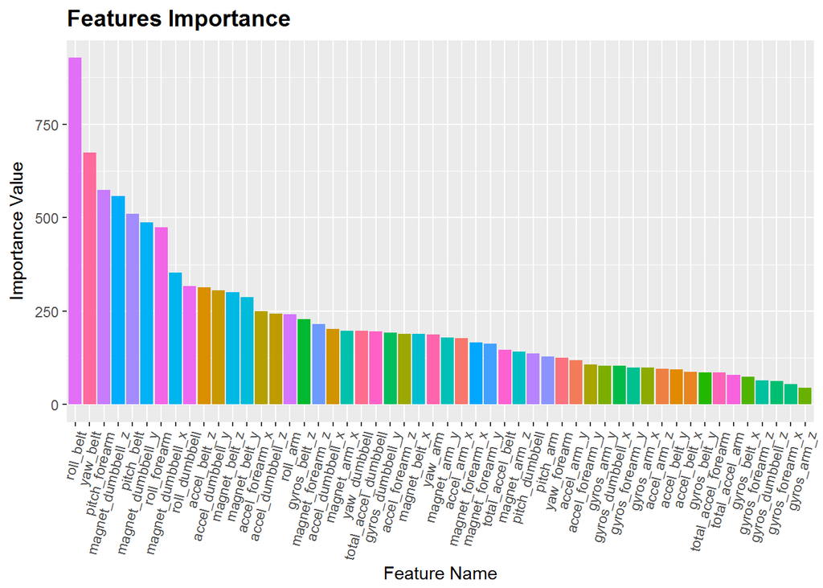

```r
library(plyr)
impVars <- varImp(fit.rf)
varnames<-rownames(impVars)
varOrders<-data.frame(varnames=varnames,impVars)
varOrders<-arrange(varOrders,desc(Overall))
ggplot(varOrders, aes(x=reorder(varnames,desc(Overall)),y=Overall,fill=varnames)) +
  geom_bar(stat="identity") + theme(legend.position="none")+
  xlab("Feature Name")+guides(fill=FALSE)+
  ylab("Importance Value")+ggtitle("Features Importance")+
  theme(axis.text.x=element_text(angle=75,hjust=1)) +
  theme(plot.title = element_text(size=14, face="bold"))
```

# Validation

```r
prediction<-predict(fit.rf,testing)
confusionMatrix(prediction,testing$classe)
```

```
## Confusion Matrix and Statistics
##
##           Reference
## Prediction    A    B    C    D    E
##          A 1395    1    0    0    0
##          B    0  946   11    0    0
##          C    0    2  843    8    0
##          D    0    0    1  796    0
##          E    0    0    0    0  901
##
## Overall Statistics
##
##                Accuracy : 0.9953
##                  95% CI : (0.993, 0.997)
##     No Information Rate : 0.2845
##     P-Value [Acc > NIR] : < 2.2e-16
##
##                   Kappa : 0.9941
##  Mcnemar's Test P-Value : NA
##
## Statistics by Class:
##
##                      Class: A Class: B Class: C Class: D Class: E
## Sensitivity            1.0000   0.9968   0.9860   0.9900   1.0000
## Specificity            0.9997   0.9972   0.9975   0.9998   1.0000
## Pos Pred Value         0.9993   0.9885   0.9883   0.9987   1.0000
## Neg Pred Value         1.0000   0.9992   0.9970   0.9981   1.0000
## Prevalence             0.2845   0.1935   0.1743   0.1639   0.1837
## Detection Rate         0.2845   0.1929   0.1719   0.1623   0.1837
## Detection Prevalence   0.2847   0.1951   0.1739   0.1625   0.1837
## Balanced Accuracy      0.9999   0.9970   0.9917   0.9949   1.0000
```

# Final Prediction

```r
predict(fit.rf,submitdata)
```

```
##  1  2  3  4  5  6  7  8  9 10 11 12 13 14 15 16 17 18 19 20
##  B  A  B  A  A  E  D  B  A  A  B  C  B  A  E  E  A  B  B  B
## Levels: A B C D E
```

Submitting above result to the grader, we can get the perfect 100% correctness.